# Análisis estadístico y geoespacial de la rentabilidad agrícola en el municipio de La Paz, Cesar

Nedilson Pushaina Ramirez

12 de marzo de 2026

## 0.1 INTRODUCCION

El sector agrícola constituye una de las principales actividades económicas en el municipio de La Paz, Cesar, desempeñando un papel fundamental en la generación de ingresos, el empleo rural y el abastecimiento de alimentos en la región. En este contexto, conocer la distribución territorial de los productores agrícolas y la estructura de las principales líneas productivas resulta esencial para comprender la dinámica agrícola del municipio y establecer una base sólida para posteriores análisis de productividad y rentabilidad.

En esta segunda etapa del trabajo se profundizó en el análisis de la información previamente recopilada, a partir de la cual se consolidaron bases de datos depuradas que permiten examinar la distribución de los productores agrícolas por vereda y la participación de las principales líneas productivas del municipio.

A partir de este proceso, se desarrollaron análisis estadísticos y representaciones geoespaciales que permitieron identificar patrones de concentración territorial de los productores, así como la predominancia de cultivos como el café, el cacao y la yuca dentro del sistema agrícola local. Estos resultados evidencian una estructura productiva diferenciada a nivel territorial, la cual constituye un insumo fundamental para el análisis posterior de la rentabilidad de los sistemas agrícolas en el municipio de La Paz, Cesar.

## 0.2 METODOLOGIA

En esta etapa del trabajo se llevó a cabo la depuración, integración y análisis de la información suministrada por la Unidad Municipal de Asistencia Técnica Agropecuaria (UMATA). Inicialmente, la base de datos incluía tanto actividades agrícolas como algunas de carácter pecuario; sin embargo, dado que el enfoque del estudio está orientado al análisis de los sistemas agrícolas, se realizó un proceso de depuración para seleccionar únicamente las líneas productivas estrictamente agrícolas.

Posteriormente, se realizó la homologación de nombres entre las bases de datos y la cartografía de veredas, con el fin de garantizar la correcta integración de la información espacial. A partir de este proceso, se consolidaron bases de datos estructuradas que permitieron desarrollar análisis estadísticos y geoespaciales orientados a identificar patrones de distribución, concentración y especialización productiva en el municipio.

Con el fin de delimitar el alcance del análisis y dar continuidad al desarrollo del estudio, se estableció que la evaluación de la rentabilidad se enfocará en los principales cultivos agrícolas identificados en el municipio, específicamente café, cacao y yuca, debido a su alta representatividad dentro del sistema productivo local.

No obstante, dado que la información necesaria para el cálculo detallado de indicadores productivos y económicos, como el rendimiento y los costos de producción, aún se encuentra en proceso de consolidación, en esta etapa el análisis se centró en la caracterización estadística y espacial de dichos cultivos. El análisis de rendimiento y rentabilidad será desarrollado en la siguiente fase del estudio, una vez se complete la base de datos correspondiente.

## 0.3 BASES DE DATOS

En esta sección se presentan las bases de datos utilizadas para el análisis de la actividad agrícola en el municipio de La Paz, Cesar. La primera base de datos contiene la distribución de los productores agrícolas por vereda, lo que permite identificar la concentración territorial de la actividad productiva. La segunda base de datos corresponde a la distribución de los principales cultivos agrícolas, específicamente café, cacao y yuca, y el número de productores asociados a cada uno en las diferentes veredas del municipio.

Estas bases de datos fueron depuradas y estructuradas para garantizar su consistencia y compatibilidad con la información geoespacial disponible, constituyendo el insumo principal para el desarrollo de los análisis estadísticos y cartográficos realizados en esta etapa del estudio.

### 0.3.1 Distribución de productores agropecuarios por corregimientos y veredas

| CORREGIMIENTOS Y VEREDAS | PRODUCTORES AGROPECUARIOS |
| --- | --- |
| Alto Riecito | 6 |
| Bella Luz | 1 |
| Brisas del chiriaimo | 10 |
| Caracoli Hueco | 1 |
| El Tambo (Las Mesas) | 26 |
| El Tesoro | 10 |
| Filo de Machete | 24 |
| La Bodega - Laguna de los Indios | 43 |
| La Cabana | 56 |
| La Frontera | 7 |
| La laguna | 22 |
| La Quiebra | 12 |
| Los Andes | 20 |
| Los deseos | 18 |
| Nuevo Oriente | 44 |
| Riecito Bajo | 4 |
| Sabana Rubia | 40 |
| Santo Tomas | 32 |
| Tierras Nuevas | 1 |
| Varas Blanca | 26 |

Con el fin de identificar las zonas con mayor concentración de actividad agropecuaria, se realizó un análisis de las veredas con mayor número de productores.

[output not shown]

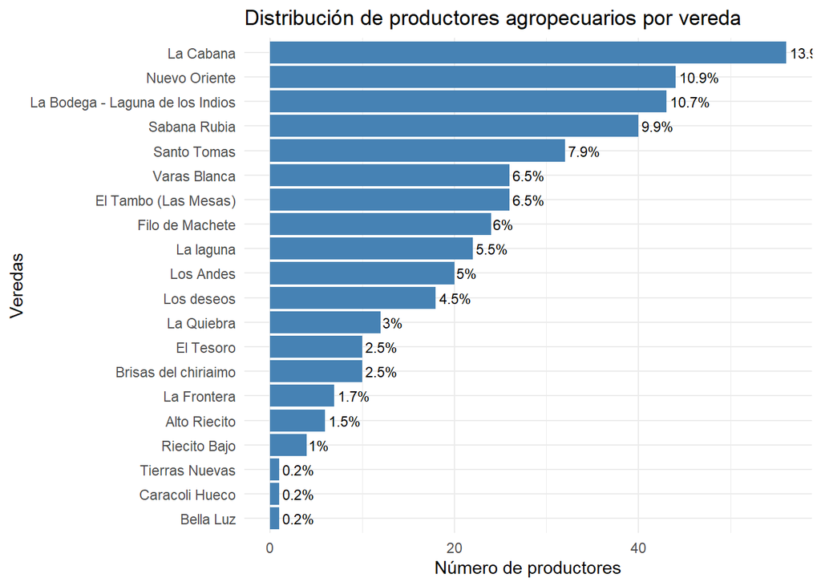

### 0.3.2 Distribución de unidades productivas por línea productiva

La siguiente Tabla muestra la distribución de las principales líneas productivas registradas en el municipio de La Paz, Cesar. Esta información permite identificar los cultivos y actividades agropecuarias predominantes dentro del sistema productivo local.

| Línea Productiva | Unidades Productivas |
| --- | --- |
| Aguacate | 5 |
| Ahuyama | 4 |
| Cacao | 72 |
| Café | 170 |
| Cebolla | 2 |
| Cilantro | 18 |
| Fresa | 1 |
| Frijol | 61 |
| Habichuela | 1 |
| Lulo | 8 |
| Maíz | 7 |
| Malanga | 1 |
| Maracuyá | 1 |
| Mora | 2 |
| Papaya | 1 |
| Patilla | 1 |
| Pimentón | 2 |
| Plátano | 9 |
| Tomate | 5 |
| Tomate De Árbol | 2 |
| Yuca | 30 |

La siguiente tabla muestra las líneas productivas con mayor presencia en el municipio de La Paz, Cesar, de acuerdo con el número de unidades productivas registradas. Esta información permite reconocer la composición general de la estructura productiva municipal.

```
## # A tibble: 10 × 3
##    `Línea Productiva` `Unidades Productivas` porcentaje
##    <chr>                               <dbl>      <dbl>
##  1 Café                                  170      41.2
##  2 Cacao                                  72      17.4
##  3 Frijol                                 61      14.8
##  4 Yuca                                   30       7.26
##  5 Cilantro                               18       4.36
##  6 Plátano                                 9       2.18
##  7 Lulo                                    8       1.94
##  8 Maíz                                    7       1.69
##  9 Aguacate                                5       1.21
## 10 Tomate                                  5       1.21
```

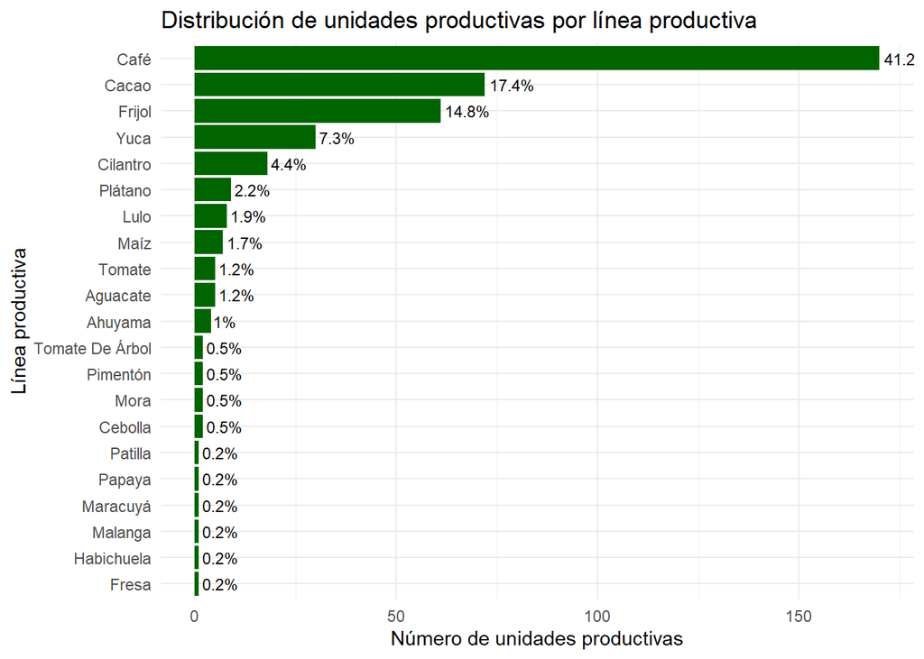

La Figura presenta la distribución de las unidades productivas por línea productiva en el municipio de La Paz, Cesar. Se observa que el café concentra la mayor proporción de unidades productivas, seguido por cacao y frijol. Estos cultivos representan una parte significativa de la estructura agrícola del municipio, lo que evidencia su importancia dentro de la dinámica productiva local.

## 0.4 Distribución espacial de productores agrícolas por vereda

El siguiente mapa representa la distribución espacial de los productores agrícolas en el municipio de La Paz, Cesar, a nivel de vereda. La información fue construida a partir de la integración entre la base de datos suministrada por la UMATA y el shapefile de veredas del municipio, permitiendo visualizar de manera geográfica la concentración de la actividad agrícola en el territorio. La intensidad del color refleja el número de productores presentes en cada vereda, mientras que aquellas sin información disponible se representan en color gris.

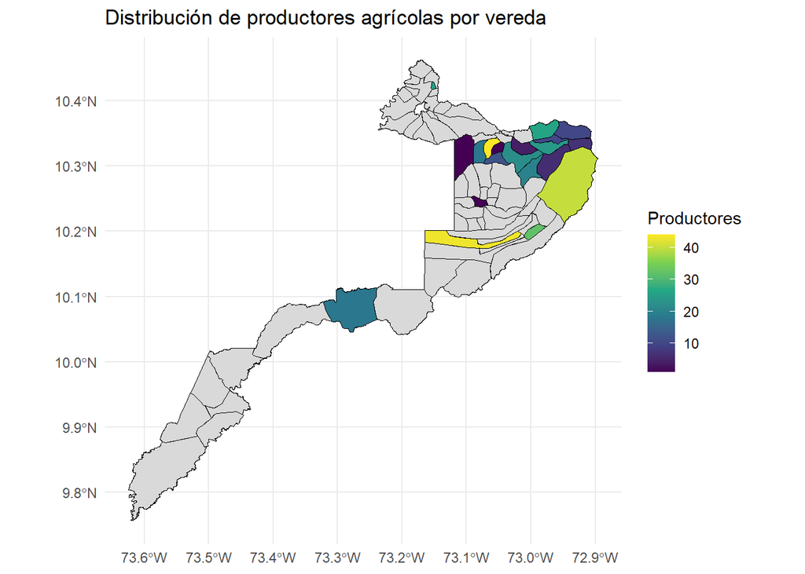

A partir del análisis del mapa, se observa que la actividad agrícola no se distribuye de manera homogénea en el municipio, sino que presenta una clara concentración en determinadas veredas. Destacan zonas con alta densidad de productores, como algunas ubicadas en la parte central y nororiental del territorio, donde los valores superan los 40 productores, lo que indica una mayor dinámica agrícola en estas áreas. Por otro lado, existen veredas con menor número de productores, evidenciando una menor intensidad productiva o una posible subrepresentación en la base de datos. Asimismo, se identifican veredas sin información, lo que sugiere limitaciones en la cobertura de los datos disponibles. En conjunto, estos patrones permiten identificar áreas prioritarias para el desarrollo agrícola y constituyen un insumo importante para la planificación territorial y la toma de decisiones en el sector agropecuario.

## 0.5 Distribución espacial de productores de café, cacao y yuca por vereda

El siguiente mapa muestra la distribución espacial de los productores asociados a los principales cultivos agrícolas del municipio de La Paz, Cesar.

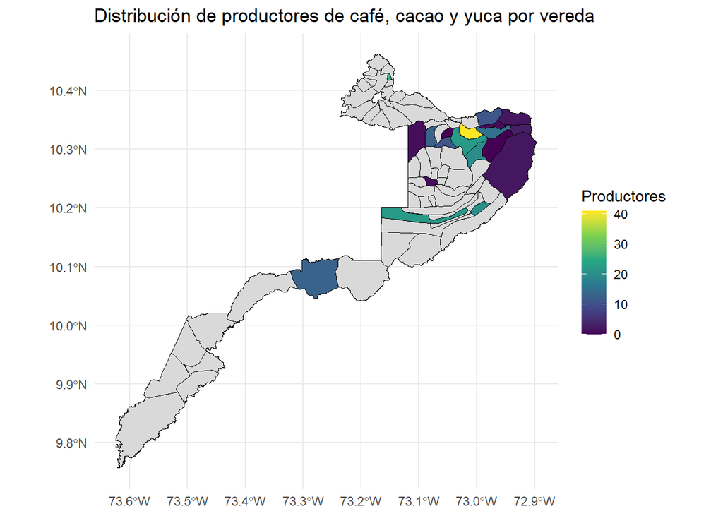

El análisis del mapa evidencia que los productores de café, cacao y yuca se concentran principalmente en ciertas veredas del municipio, mostrando una distribución territorial diferenciada. Se destacan algunas zonas con alta presencia de estos cultivos, especialmente en el sector nororiental, donde se registran los mayores valores de productores, lo que sugiere una mayor especialización agrícola en estas áreas. En contraste, otras veredas presentan una baja participación o ausencia de estos sistemas productivos, lo cual puede estar asociado a condiciones agroambientales, acceso a recursos o dinámicas productivas locales. Este patrón espacial permite identificar las áreas donde se concentra la producción agrícola más representativa del municipio y constituye una base importante para el análisis posterior de la rentabilidad y la planificación del desarrollo agricola.

## 0.6 Cultivo predominante por vereda en el municipio de La Paz, Cesar

El siguiente mapa presenta la distribución espacial del cultivo predominante en cada vereda del municipio de La Paz, Cesar, considerando exclusivamente los sistemas agrícolas de café, cacao y yuca. A partir de la información consolidada, se identificó el cultivo con mayor número de productores en cada unidad territorial, permitiendo visualizar los patrones de especialización agrícola en el territorio. Cada color representa el cultivo dominante, mientras que las veredas sin información disponible se muestran en gris.

[interactive chart not shown]

El análisis del mapa evidencia una clara diferenciación espacial en la predominancia de los cultivos agrícolas dentro del municipio. Se observa que el café presenta una mayor concentración en varias veredas del sector nororiental, lo que sugiere condiciones favorables para su producción en estas zonas. Por su parte, el cacao aparece como cultivo predominante en algunas veredas específicas, indicando una distribución más focalizada, mientras que la yuca tiene una presencia más limitada y dispersa en el territorio. Estas diferencias reflejan procesos de especialización agrícola asociados a factores como condiciones agroambientales, disponibilidad de recursos y dinámicas productivas locales. En conjunto, el mapa permite identificar áreas con vocación productiva diferenciada, lo cual resulta fundamental para orientar estrategias de planificación agrícola y análisis posteriores de rentabilidad.

# 1 Análisis estadístico y territorial de los sistemas agrícolas

## 1.1 Tabla resumen de productores por vereda y cultivo

Con el fin de integrar la información productiva a nivel territorial, se construyó una tabla resumen que consolida el número total de productores agrícolas por vereda, así como su distribución en los principales cultivos analizados (café, cacao y yuca). Además, se identificó el cultivo predominante en cada vereda, lo que permite una mejor comprensión de la especialización productiva del territorio.

Tabla resumen de productores por vereda y cultivo

| vereda | productores | cafe | cacao | yuca | total | dominante |
| --- | --- | --- | --- | --- | --- | --- |
| Alto Riecito | 6 | 0 | 0 | 0 | 0 | Café |
| Bella Luz | 1 | 0 | 0 | 1 | 1 | Yuca |
| Brisas del chiriaimo | 10 | 2 | 0 | 0 | 2 | Café |
| Caracoli Hueco | 1 | 0 | 1 | 0 | 1 | Cacao |
| El Tambo (Las Mesas) | 26 | 11 | 0 | 0 | 11 | Café |
| El Tesoro | 10 | 1 | 0 | 0 | 1 | Café |
| Filo de Machete | 24 | 15 | 0 | 0 | 15 | Café |
| La Bodega - Laguna de los Indios | 43 | 5 | 17 | 0 | 22 | Cacao |
| La Cabana | 56 | 40 | 0 | 0 | 40 | Café |
| La Frontera | 7 | 3 | 0 | 0 | 3 | Café |
| La laguna | 22 | 21 | 1 | 0 | 22 | Café |
| La Quiebra | 12 | 10 | 1 | 0 | 11 | Café |
| Los Andes | 20 | 20 | 0 | 0 | 20 | Café |
| Los deseos | 18 | 1 | 10 | 2 | 13 | Cacao |
| Nuevo Oriente | 44 | NA | NA | NA | NA | NA |
| Riecito Bajo | 4 | 0 | 40 | 1 | 41 | Cacao |
| Sabana Rubia | 40 | 1 | 1 | 0 | 2 | Café |
| Sabana Rubia | 40 | 21 | 0 | 0 | 21 | Café |
| Santo Tomas | 32 | 19 | 1 | 0 | 20 | Café |
| Tierras Nuevas | 1 | 0 | 0 | 0 | 0 | Café |
| Varas Blanca | 26 | 0 | 0 | 26 | 26 | Yuca |

A partir de la tabla se evidencia que la distribución de los productores agrícolas es heterogénea entre las veredas del municipio, destacándose algunas con alta concentración de productores como La Cabaña, Nuevo Oriente, La Bodega - Laguna de los Indios y Sabana Rubia. En términos de especialización productiva, el café se posiciona como el cultivo predominante en la mayoría de las veredas, lo que confirma su importancia dentro del sistema agrícola local. Por su parte, el cacao presenta una presencia significativa en veredas específicas como Riecito Bajo, La Bodega - Laguna de los Indios y Los Deseos, evidenciando una distribución más focalizada. En contraste, la yuca muestra una menor participación general, destacándose principalmente en la vereda Varas Blanca.

## 1.2 Análisis de los principales cultivos agrícolas

Con el fin de analizar la importancia relativa de los principales sistemas agrícolas del municipio, se calcularon los totales y porcentajes de participación de los cultivos de café, cacao y yuca, a partir del número de productores asociados a cada uno de ellos.

Participación de los principales cultivos agrícolas

| cultivo | productores | porcentaje |
| --- | --- | --- |
| Café | 170 | 62.50000 |
| Cacao | 72 | 26.47059 |
| Yuca | 30 | 11.02941 |

Los resultados evidencian que el café es el cultivo con mayor participación dentro del sistema agrícola del municipio, concentrando el mayor número de productores, lo que confirma su relevancia económica y territorial. En segundo lugar, se encuentra el cacao, el cual presenta una participación significativa, aunque menor en comparación con el café, y con una distribución más focalizada en determinadas veredas. Por su parte, la yuca registra la menor participación dentro de los cultivos analizados, lo que indica una menor representatividad en términos de número de productores.

## 1.4 CONCLUSIONES

El análisis desarrollado permitió caracterizar la distribución territorial de los productores agrícolas en el municipio de La Paz, Cesar, evidenciando una concentración espacial diferenciada a nivel de vereda. A partir de la depuración e integración de las bases de datos, fue posible identificar patrones de localización que reflejan una organización no homogénea de la actividad agrícola en el territorio.

Asimismo, se determinó que el sistema agrícola del municipio presenta una clara predominancia del cultivo de café, tanto en términos de número de productores como en su distribución espacial, lo que lo posiciona como la principal actividad productiva. En segundo lugar, el cacao muestra una participación significativa, concentrándose en veredas específicas, mientras que la yuca presenta una menor representatividad y una distribución más limitada dentro del territorio.

Por otra parte, el uso de herramientas geoespaciales permitió visualizar de manera clara los patrones de concentración y especialización agrícola, evidenciando que la distribución de los cultivos responde a dinámicas territoriales particulares. Estos resultados constituyen un insumo fundamental para la comprensión del sistema agrícola local y resaltan la importancia de considerar el componente espacial en el análisis productivo.

Finalmente, esta etapa del estudio proporciona una base sólida para el desarrollo de la siguiente fase, en la cual se abordará el análisis de la rentabilidad de los sistemas agrícolas, incorporando variables productivas, económicas y agroambientales que permitan evaluar el desempeño de los principales cultivos en el municipio.